# Tugas Pertemuan 1 MPDW

Anis Sulistiyowati

2023-09-04

# Library

```r
library("forecast")
```

```r
library("graphics")
library("TTR")
library("TSA")
```

# Impor Data

```r
library(rio)
datachicken <- import("https://raw.githubusercontent.com/Anissls333/mpdw/main/data/data.csv")
```

# Eksplorasi Data

```r
View(datachicken)
str(datachicken)
```

```
## 'data.frame':    201 obs. of  2 variables:
##  $ Periode: int  1 2 3 4 5 6 7 8 9 10 ...
##  $ Price  : num  30.7 30 30 29.3 29.3 ...
```

```r
dim(datachicken)
```

```
## [1] 201   2
```

Mengubah data agar terbaca sebagai data deret waktu

```r
datachicken.ts <- ts(datachicken$Price)
str(datachicken.ts)
```

```
##  Time-Series [1:201] from 1 to 201: 30.7 30 30 29.3 29.3 ...
```

## Menampilkan ringkasan data

```r
summary(datachicken.ts)
```

```
##    Min. 1st Qu.  Median    Mean 3rd Qu.    Max.
##   25.00   28.67   30.67   31.06   34.00   35.67
```

## Membuat plot

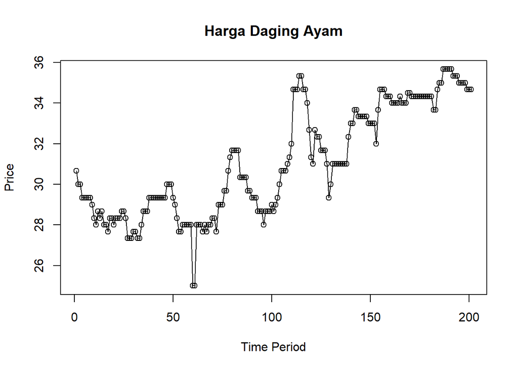

```r
ts.plot(datachicken.ts, xlab="Time Period", ylab="Price",
        main = "Harga Daging Ayam")
#membuat titik2 di plot data
points(datachicken.ts)
```

# Pemulusan (Smoothing)

## Double Moving Average (DMA)

### Pembagian Data

```r
#membagi 86% data latih (training) dan 14% data uji (testing)
training_ma <- datachicken[1:173,]
testing_ma <- datachicken[174:201,]
train_ma.ts <- ts(training_ma$Price)
test_ma.ts <- ts(testing_ma$Price)
```

### Eksplorasi Data

Eksplorasi data dilakukan pada keseluruhan data, data latih serta data uji menggunakan plot data deret waktu.

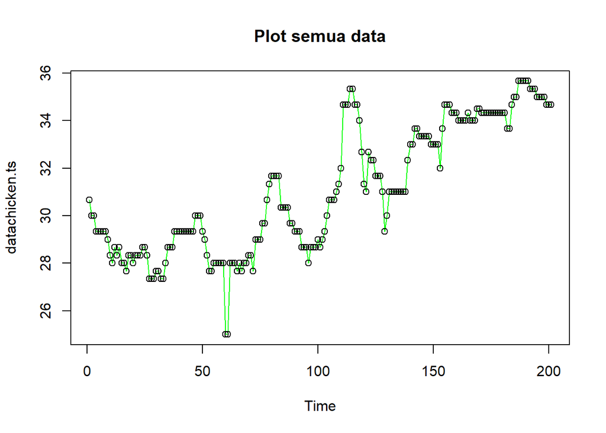

```r
#eksplorasi keseluruhan data
plot(datachicken.ts, col="green",main="Plot semua data")
points(datachicken.ts)
```

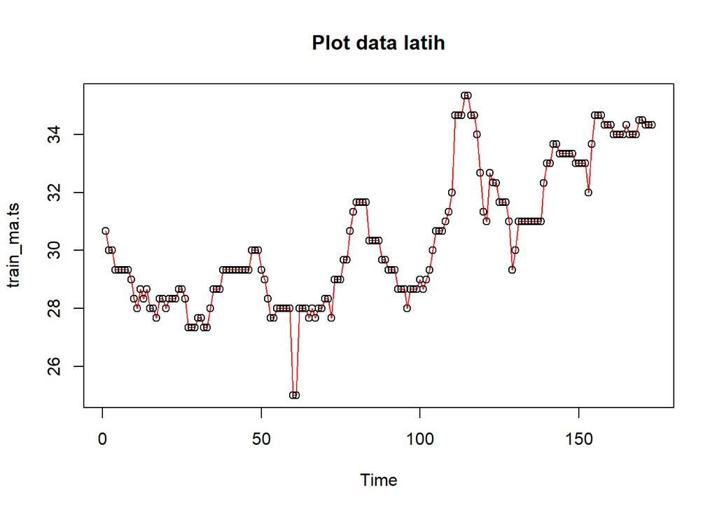

```r
#eksplorasi data latih
plot(train_ma.ts, col="red",main="Plot data latih")
points(train_ma.ts)
```

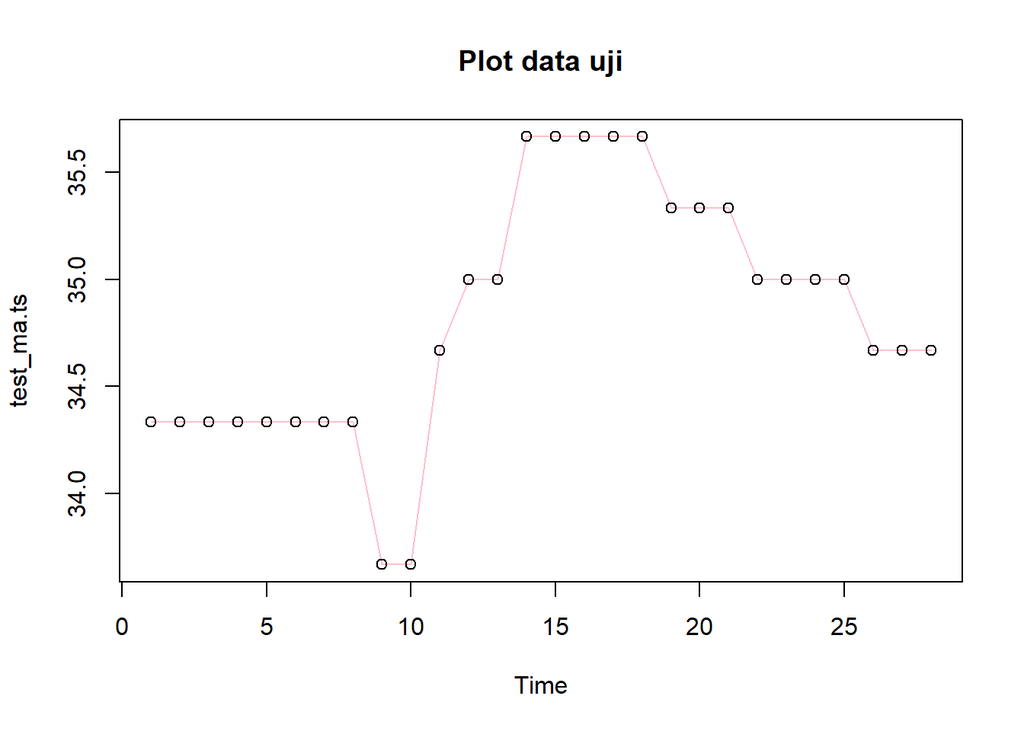

```r
#eksplorasi data uji
plot(test_ma.ts, col="pink",main="Plot data uji")
points(test_ma.ts)
```

Eksplorasi data juga dapat dilakukan menggunakan package `ggplot2` .

```r
#Eksplorasi dengan GGPLOT

library(ggplot2)
ggplot() +
  geom_line(data = training_ma, aes(x = Periode, y = Price, col = "Data Latih")) +
  geom_line(data = testing_ma, aes(x = Periode, y = Price, col = "Data Uji")) +
  labs(x = "Periode Waktu", y = "Harga Rata-rata", color = "Legend") +
  scale_colour_manual(name="Keterangan:", breaks = c("Data Latih", "Data Uji"),
                      values = c("purple", "red")) +
  theme_bw() + theme(legend.position = "bottom",
                     plot.caption = element_text(hjust=0.5, size=13))
```

[output not shown]

### Metode DMA

Metode pemulusan Double Moving Average (DMA) pada dasarnya mirip dengan SMA. Namun demikian, metode ini lebih cocok digunakan untuk pola data trend. Proses pemulusan dengan rata rata dalam metode ini dilakukan sebanyak 2 kali.

```r
data.sma <- SMA(train_ma.ts, n=4)

dma <- SMA(data.sma, n = 4)
At <- 2*data.sma - dma
Bt <- 2/(4-1)*(data.sma - dma)
data.dma<- At+Bt
data.ramal2<- c(NA, data.dma)

t = 1:28
f = c()

for (i in t) {
  f[i] = At[length(At)] + Bt[length(Bt)]*(i)
}

data.gab2 <- cbind(aktual = c(train_ma.ts,rep(NA,28)), pemulusan1 = c(data.sma,rep(NA,28)),pemulusan2 = c(data.dma, rep(NA,28)),At = c(At, rep(NA,28)), Bt = c(Bt,rep(NA,28)),ramalan = c(data.ramal2, f[-1]))
data.gab2
```

```
##        aktual pemulusan1 pemulusan2       At            Bt  ramalan
##   [1,] 30.667         NA         NA       NA            NA       NA
##   [2,] 30.000         NA         NA       NA            NA       NA
##   [3,] 30.000         NA         NA       NA            NA       NA
##   [4,] 29.333   30.00000         NA       NA            NA       NA
##   [5,] 29.333   29.66650         NA       NA            NA       NA
##   [6,] 29.333   29.49975         NA       NA            NA       NA
##   [7,] 29.333   29.33300   28.84665 29.04119 -1.945417e-01       NA
##   [8,] 29.333   29.33300   29.12456 29.20794 -8.337500e-02 28.84665
##   [9,] 29.000   29.24975   29.07621 29.14562 -6.941667e-02 29.12456
##  [10,] 28.333   28.99975   28.61788 28.77063 -1.527500e-01 29.07621
##  [11,] 28.000   28.66650   28.00692 28.27075 -2.638333e-01 28.61788
##  [12,] 28.667   28.50000   27.91000 28.14600 -2.360000e-01 28.00692
##  [13,] 28.333   28.33325   27.84721 28.04163 -1.944167e-01 27.91000
##  [14,] 28.667   28.41675   28.31279 28.35438 -4.158333e-02 27.84721
```

[output cut: 187 more lines]

### Visualisasi

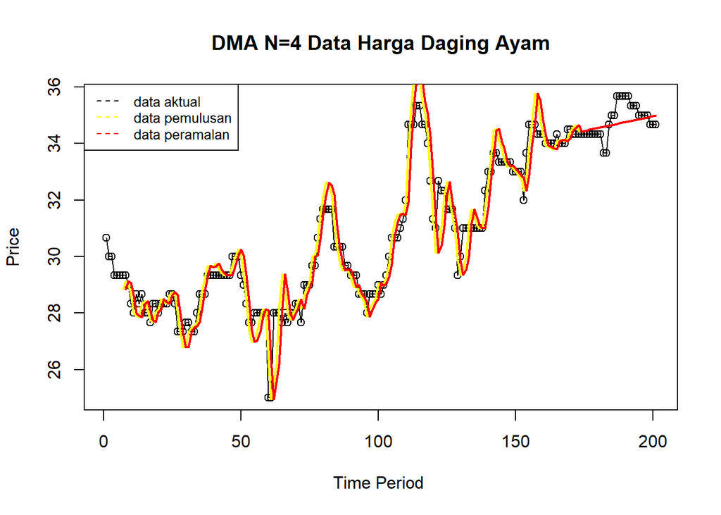

```r
ts.plot(datachicken.ts, xlab="Time Period ", ylab="Price", main= "DMA N=4 Data Harga Daging Ayam")
points(datachicken.ts)
lines(data.gab2[,3],col="yellow",lwd=2)
lines(data.gab2[,6],col="red",lwd=2)
legend("topleft",c("data aktual","data pemulusan","data peramalan"), lty=8, col=c("black","yellow","red"), cex=0.8)
```

### Akurasi Data Latih

```r
error_train.dma = train_ma.ts-data.ramal2[1:length(train_ma.ts)]
SSE_train.dma = sum(error_train.dma[8:length(train_ma.ts)]^2)
MSE_train.dma = mean(error_train.dma[8:length(train_ma.ts)]^2)
MAPE_train.dma = mean(abs((error_train.dma[8:length(train_ma.ts)]/train_ma.ts[8:length(train_ma.ts)])*100))

akurasi_train.dma <- matrix(c(SSE_train.dma, MSE_train.dma, MAPE_train.dma))
row.names(akurasi_train.dma)<- c("SSE", "MSE", "MAPE")
colnames(akurasi_train.dma) <- c("Akurasi m = 4")
akurasi_train.dma
```

```
##      Akurasi m = 4
## SSE    123.8826868
## MSE      0.7462812
## MAPE     2.0460170
```

Perhitungan akurasi menggunakan data latih menghasilkan nilai MAPE yang kurang dari 10% sehingga nilai akurasi ini dapat dikategorikan sebagai sangat baik.

### Akurasi Data Uji

```r
error_test.dma = test_ma.ts-data.gab2[174:201,6]
SSE_test.dma = sum(error_test.dma^2)
MSE_test.dma = mean(error_test.dma^2)
MAPE_test.dma = mean(abs((error_test.dma/test_ma.ts*100)))

akurasi_test.dma <- matrix(c(SSE_test.dma, MSE_test.dma, MAPE_test.dma))
row.names(akurasi_test.dma)<- c("SSE", "MSE", "MAPE")
colnames(akurasi_test.dma) <- c("Akurasi m = 4")
akurasi_test.dma
```

```
##      Akurasi m = 4
## SSE      7.6421739
## MSE      0.2729348
## MAPE     1.1650293
```

Perhitungan akurasi menggunakan data uji menghasilkan nilai MAPE yang kurang dari 10% sehingga nilai akurasi ini dapat dikategorikan sebagai sangat baik.

## Double Exponential Smoothing (DES)

Metode *Exponential Smoothing* adalah metode pemulusan dengan melakukan pembobotan menurun secara eksponensial. Nilai yang lebih baru diberi bobot yang lebih besar dari nilai terdahulu. Terdapat satu atau lebih parameter pemulusan yang ditentukan secara eksplisit dan hasil pemilihan parameter tersebut akan menentukan bobot yang akan diberikan pada nilai pengamatan.

### Pembagian Data

Pembagian data latih dan data uji dilakukan dengan perbandingan 86% data latih dan 14% data uji.

```r
#membagi 86% data latih (training) dan 14% data uji (testing)
training <- datachicken[1:173,]
testing  <- datachicken[174:201,]
train.ts <- ts(training$Price)
test.ts  <- ts(testing$Price)
```

### Eksplorasi Data

Membuat plot data deret waktu untuk keseluruhan data, data latih, dan data uji.

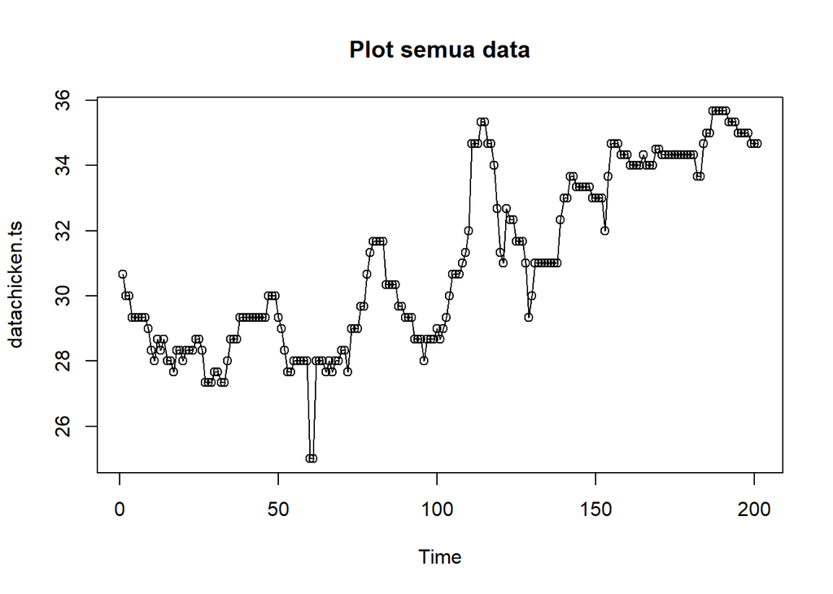

```r
#eksplorasi data
plot(datachicken.ts, col="black",main="Plot semua data")
points(datachicken.ts)
```

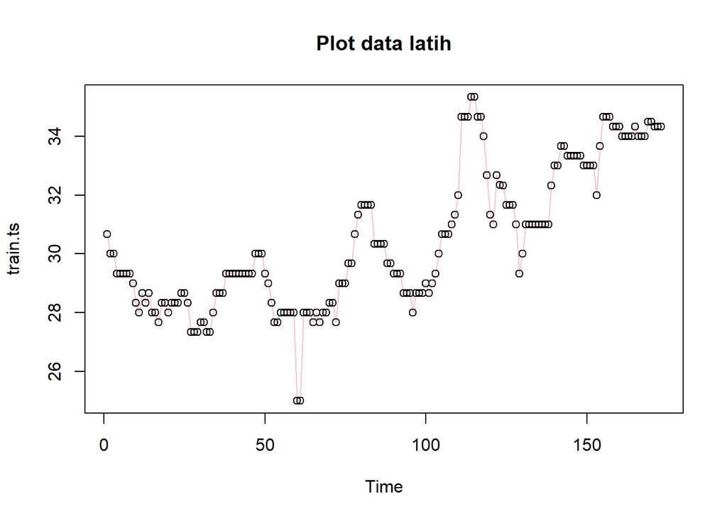

```r
plot(train.ts, col="pink",main="Plot data latih")
points(train.ts)
```

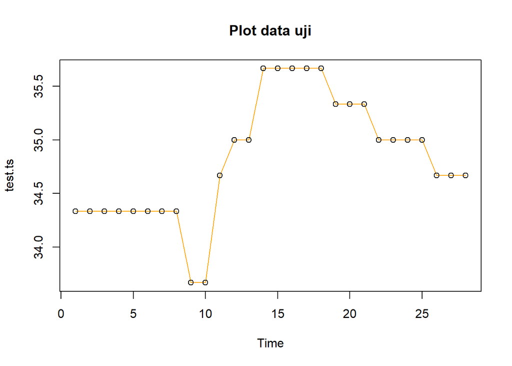

```r
plot(test.ts, col="orange",main="Plot data uji")
points(test.ts)
```

Eksplorasi data juga dapat dilakukan menggunakan package `ggplot2` .

```r
#Eksplorasi dengan GGPLOT
library(ggplot2)
ggplot() +
  geom_line(data = training, aes(x = Periode, y = Price, col = "Data Latih")) +
  geom_line(data = testing, aes(x = Periode, y = Price, col = "Data Uji")) +
  labs(x = "Periode Waktu", y = "Harga Rata-rata", color = "Legend") +
  scale_colour_manual(name="Keterangan:", breaks = c("Data Latih", "Data Uji"),
                      values = c("purple", "red")) +
  theme_bw() + theme(legend.position = "bottom",
                     plot.caption = element_text(hjust=0.5, size=12))
```

[output not shown]

### Metode DES

Metode pemulusan DES digunakan untuk data yang memiliki pola tren. Metode DES adalah metode semacam SES, hanya saja dilakukan dua kali, yaitu pertama untuk tahapan ‘level’ dan kedua untuk tahapan ‘tren’. Pemulusan menggunakan metode ini akan menghasilkan peramalan tidak konstan untuk periode berikutnya.

Pemulusan dengan metode DES ini akan menggunakan fungsi `HoltWinters()` . Nilai argumen `beta` diinisialisasi bersamaan dengan nilai `alpha` dan nilai argumen `gamma` dibuat `FALSE`.

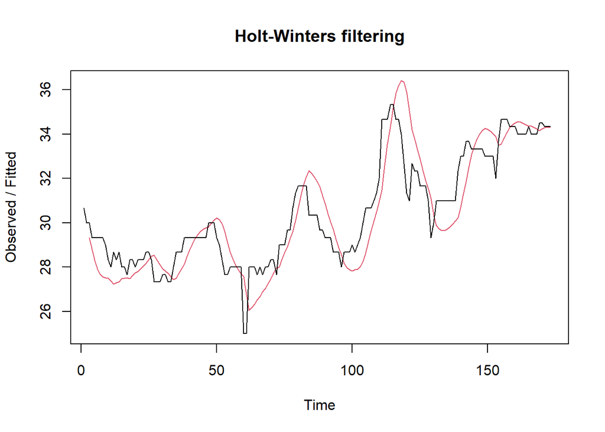

```r
#beta=0.2 dan alpha=0.2
des.1<- HoltWinters(train.ts, gamma = FALSE, beta = 0.2, alpha = 0.2)
plot(des.1)
```

```r
#ramalan
ramalandes1<- forecast(des.1, h=28)     #h = panjang periode
ramalandes1
```

```
##     Point Forecast    Lo 80    Hi 80    Lo 95    Hi 95
## 174       34.33264 32.78461 35.88067 31.96513 36.70015
## 175       34.34236 32.75037 35.93435 31.90762 36.77710
## 176       34.35208 32.70213 36.00202 31.82870 36.87545
## 177       34.36179 32.63909 36.08450 31.72715 36.99644
## 178       34.37151 32.56091 36.18211 31.60243 37.14059
## 179       34.38123 32.46767 36.29479 31.45469 37.30776
## 180       34.39095 32.35978 36.42211 31.28454 37.49735
## 181       34.40066 32.23785 36.56348 31.09292 37.70841
## 182       34.41038 32.10262 36.71814 30.88096 37.93980
## 183       34.42010 31.95488 36.88531 30.64988 38.19032
## 184       34.42982 31.79543 37.06420 30.40087 38.45876
## 185       34.43953 31.62501 37.25406 30.13509 38.74398
## 186       34.44925 31.44431 37.45419 29.85360 39.04491
## 187       34.45897 31.25398 37.66395 29.55736 39.36057
## 188       34.46869 31.05458 37.88279 29.24726 39.69011
## 189       34.47840 30.84663 38.11018 28.92408 40.03273
## 190       34.48812 30.63057 38.34567 28.58850 40.38774
## 191       34.49784 30.40681 38.58886 28.24116 40.75452
## 192       34.50756 30.17572 38.83939 27.88258 41.13253
## 193       34.51727 29.93761 39.09694 27.51328 41.52126
## 194       34.52699 29.69277 39.36121 27.13368 41.92030
## 195       34.53671 29.44145 39.63197 26.74418 42.32924
## 196       34.54642 29.18388 39.90897 26.34513 42.74772
## 197       34.55614 28.92029 40.19200 25.93684 43.17544
## 198       34.56586 28.65084 40.48088 25.51961 43.61211
## 199       34.57558 28.37571 40.77544 25.09370 44.05745
## 200       34.58529 28.09507 41.07552 24.65935 44.51124
## 201       34.59501 27.80905 41.38097 24.21678 44.97325
```

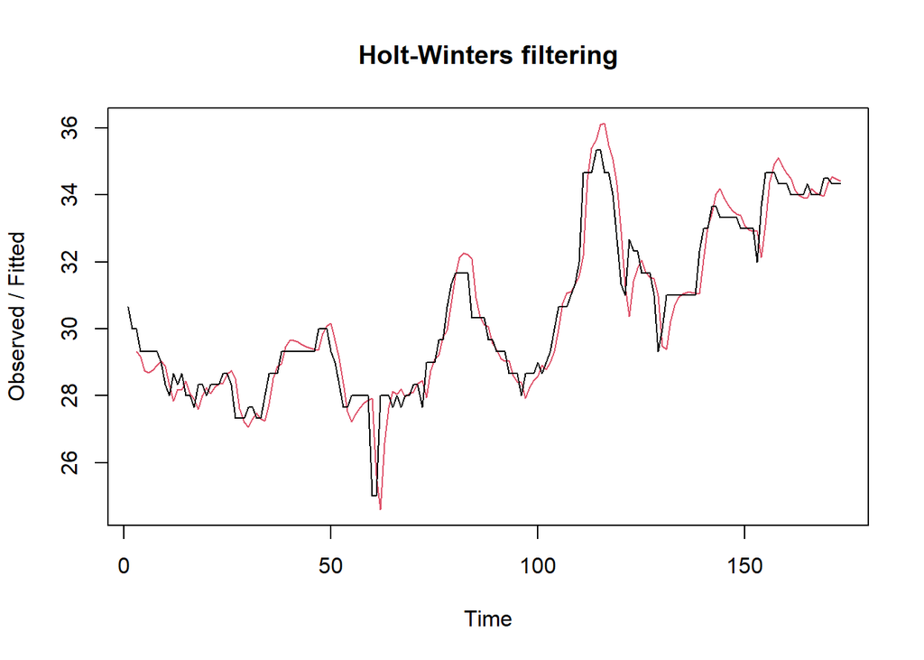

```r
#beta=0.3 dan aplha=0.6
des.2<- HoltWinters(train.ts, gamma = FALSE, beta = 0.3, alpha = 0.6)
plot(des.2)
```

```r
#ramalan
ramalandes2<- forecast(des.2, h=28)
ramalandes2
```

```
##     Point Forecast    Lo 80    Hi 80     Lo 95    Hi 95
## 174       34.38523 33.46739 35.30307 32.981518 35.78895
## 175       34.40194 33.23791 35.56597 32.621715 36.18217
## 176       34.41866 32.95874 35.87857 32.185910 36.65140
## 177       34.43537 32.63921 36.23152 31.688385 37.18235
## 178       34.45208 32.28551 36.61865 31.138596 37.76556
## 179       34.46879 31.90179 37.03579 30.542901 38.39468
## 180       34.48550 31.49098 37.48002 29.905773 39.06523
## 181       34.50221 31.05524 37.94919 29.230518 39.77391
## 182       34.51892 30.59623 38.44161 28.519686 40.51816
## 183       34.53564 30.11530 38.95597 27.775321 41.29595
## 184       34.55235 29.61355 39.49115 26.999105 42.10559
## 185       34.56906 29.09190 40.04622 26.192463 42.94565
## 186       34.58577 28.55115 40.62039 25.356620 43.81492
## 187       34.60248 27.99202 41.21294 24.492649 44.71231
## 188       34.61919 27.41511 41.82327 23.601501 45.63688
## 189       34.63590 26.82099 42.45082 22.684026 46.58778
## 190       34.65261 26.21016 43.09507 21.740996 47.56423
## 191       34.66933 25.58308 43.75557 20.773110 48.56554
## 192       34.68604 24.94016 44.43191 19.781011 49.59106
## 193       34.70275 24.28181 45.12369 18.765292 50.64021
## 194       34.71946 23.60836 45.83056 17.726500 51.71242
## 195       34.73617 22.92016 46.55218 16.665146 52.80720
## 196       34.75288 22.21752 47.28824 15.581706 53.92406
## 197       34.76959 21.50074 48.03845 14.476626 55.06256
## 198       34.78631 20.77007 48.80254 13.350324 56.22229
## 199       34.80302 20.02579 49.58024 12.203198 57.40284
## 200       34.81973 19.26813 50.37132 11.035618 58.60384
## 201       34.83644 18.49734 51.17554  9.847938 59.82494
```

Nilai `y` adalah nilai data deret waktu, `gamma` adalah parameter pemulusan untuk komponen musiman, `beta` adalah parameter pemulusan untuk tren, dan `alpha` adalah parameter pemulusan untuk stasioner, serta `h` adalah banyaknya periode yang akan diramalkan.

### Visualisasi

Membandingkan plot data latih dan data uji adalah sebagai berikut.

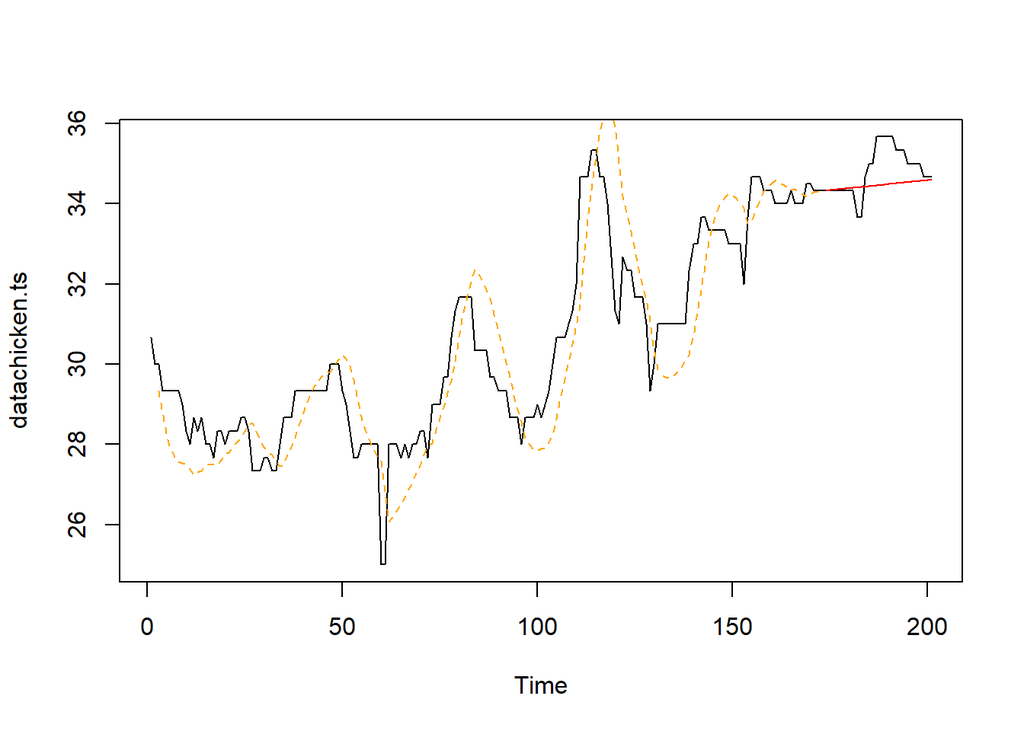

```r
#Visually evaluate the prediction
plot(datachicken.ts)
lines(des.1$fitted[,1], lty=2, col="orange")
lines(ramalandes1$mean, col="red")
```

Untuk mendapatkan nilai parameter optimum dari DES, argumen `alpha` dan `beta` dapat dibuat `NULL` seperti berikut.

```r
#Lamda dan gamma optimum
des.opt<- HoltWinters(train.ts, gamma = FALSE)
des.opt
```

```
## Holt-Winters exponential smoothing with trend and without seasonal component.
##
## Call:
## HoltWinters(x = train.ts, gamma = FALSE)
##
## Smoothing parameters:
##  alpha: 1
##  beta : 0.0762442
##  gamma: FALSE
##
## Coefficients:
##          [,1]
## a 34.33300000
## b  0.03594424
```

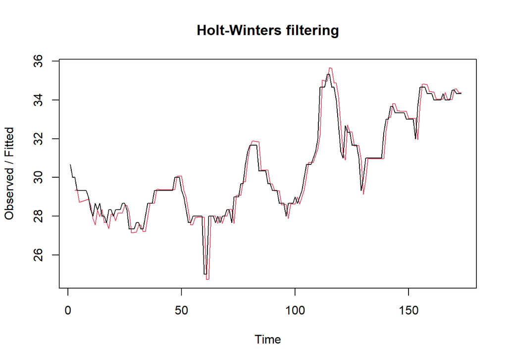

```r
plot(des.opt)
```

```r
#ramalan
ramalandesopt<- forecast(des.opt, h=28)   #h = panjang periode
ramalandesopt
```

```
##     Point Forecast    Lo 80    Hi 80    Lo 95    Hi 95
## 174       34.36894 33.54791 35.18998 33.11328 35.62461
## 175       34.40489 33.19869 35.61108 32.56017 36.24960
## 176       34.44083 32.90778 35.97389 32.09623 36.78544
## 177       34.47678 32.64157 36.31199 31.67006 37.28349
## 178       34.51272 32.38764 36.63780 31.26269 37.76275
## 179       34.54867 32.13993 36.95740 30.86483 38.23250
## 180       34.58461 31.89502 37.27420 30.47123 38.69799
## 181       34.62055 31.65078 37.59033 30.07867 39.16243
## 182       34.65650 31.40584 37.90716 29.68504 39.62795
## 183       34.69244 31.15925 38.22563 29.28890 40.09599
## 184       34.72839 30.91036 38.54641 28.88922 40.56755
## 185       34.76433 30.65869 38.86997 28.48530 41.04336
## 186       34.80028 30.40389 39.19666 28.07659 41.52396
## 187       34.83622 30.14572 39.52672 27.66272 42.00972
## 188       34.87216 29.88397 39.86035 27.24338 42.50094
## 189       34.90811 29.61852 40.19769 26.81838 42.99783
## 190       34.94405 29.34926 40.53884 26.38756 43.50054
## 191       34.98000 29.07612 40.88387 25.95080 44.00919
## 192       35.01594 28.79905 41.23283 25.50803 44.52385
## 193       35.05188 28.51801 41.58576 25.05919 45.04458
## 194       35.08783 28.23299 41.94267 24.60425 45.57141
## 195       35.12377 27.94396 42.30359 24.14319 46.10435
## 196       35.15972 27.65093 42.66850 23.67602 46.64342
## 197       35.19566 27.35390 43.03742 23.20273 47.18860
## 198       35.23161 27.05289 43.41032 22.72334 47.73987
## 199       35.26755 26.74790 43.78720 22.23787 48.29723
## 200       35.30349 26.43895 44.16804 21.74634 48.86065
## 201       35.33944 26.12606 44.55282 21.24879 49.43008
```

### Akurasi Data Latih

```r
#Akurasi Data Training
ssedes.train1<-des.1$SSE
msedes.train1<-ssedes.train1/length(train.ts)
sisaandes1<-ramalandes1$residuals
head(sisaandes1)
```

```
## Time Series:
## Start = 1
## End = 6
## Frequency = 1
## [1]       NA       NA 0.667000 0.506920 1.025579 1.399483
```

```r
mapedes.train1 <- sum(abs(sisaandes1[3:length(train.ts)]/train.ts[3:length(train.ts)])
                      *100)/length(train.ts)

akurasides.1 <- matrix(c(ssedes.train1,msedes.train1,mapedes.train1))
row.names(akurasides.1)<- c("SSE", "MSE", "MAPE")
colnames(akurasides.1) <- c("Akurasi lamda=0.2 dan gamma=0.2")
akurasides.1
```

```
##      Akurasi lamda=0.2 dan gamma=0.2
## SSE                       249.722312
## MSE                         1.443482
## MAPE                        3.112975
```

```r
ssedes.train2<-des.2$SSE
msedes.train2<-ssedes.train2/length(train.ts)
sisaandes2<-ramalandes2$residuals
head(sisaandes2)
```

```
## Time Series:
## Start = 1
## End = 6
## Frequency = 1
## [1]        NA        NA 0.6670000 0.1467400 0.5792228 0.6479558
```

```r
mapedes.train2 <- sum(abs(sisaandes2[3:length(train.ts)]/train.ts[3:length(train.ts)])
                      *100)/length(train.ts)

akurasides.2 <- matrix(c(ssedes.train2,msedes.train2,mapedes.train2))
row.names(akurasides.2)<- c("SSE", "MSE", "MAPE")
colnames(akurasides.2) <- c("Akurasi lamda=0.6 dan gamma=0.3")
akurasides.2
```

```
##      Akurasi lamda=0.6 dan gamma=0.3
## SSE                       87.2832538
## MSE                        0.5045275
## MAPE                       1.5694554
```

Hasil akurasi dari data latih didapatkan skenario 2 dengan lamda=0.6 dan gamma=0.3 memiliki hasil yang lebih baik. Hal tersebut dapat dilihat berdasarkan nilai SSE, MSE,dan MAPE nya yang bernilai lebih kecil dibandinglan dengan skenario 1. Namun, kedua skenario tersebut dapat dikategorikan peramalan sangat baik berdasarkan nilai MAPE-nya.

### Akurasi Data Uji

```r
#Akurasi Data Testing
selisihdes1 <- ramalandes1$mean - testing$Price
selisihdes1
```

```
## Time Series:
## Start = 174
## End = 201
## Frequency = 1
##  [1] -0.000359482  0.009357991  0.019075464  0.028792936  0.038510409
##  [6]  0.048227882  0.057945355  0.067662828  0.743380301  0.753097773
## [11] -0.237184754 -0.560467281 -0.550749808 -1.208032335 -1.198314862
## [16] -1.188597390 -1.178879917 -1.169162444 -0.825444971 -0.815727498
## [21] -0.806010025 -0.463292553 -0.453575080 -0.443857607 -0.434140134
## [26] -0.091422661 -0.081705188 -0.071987716
```

```r
SSEtestingdes1<-sum(selisihdes1^2)
MSEtestingdes1<-SSEtestingdes1/length(testing$Price)
MAPEtestingdes1<-sum(abs(selisihdes1/testing$Price)*100)/length(testing$Price)

selisihdes2<-ramalandes2$mean-testing$Price
selisihdes2
```

```
## Time Series:
## Start = 174
## End = 201
## Frequency = 1
##  [1]  0.05223333  0.06894466  0.08565599  0.10236732  0.11907865  0.13578998
##  [7]  0.15250131  0.16921264  0.85192396  0.86863529 -0.11465338 -0.43094205
## [13] -0.41423072 -1.06451939 -1.04780806 -1.03109673 -1.01438540 -0.99767407
## [19] -0.64696274 -0.63025142 -0.61354009 -0.26382876 -0.24711743 -0.23040610
## [25] -0.21369477  0.13601656  0.15272789  0.16943922
```

```r
SSEtestingdes2<-sum(selisihdes2^2)
MSEtestingdes2<-SSEtestingdes2/length(testing$Price)
MAPEtestingdes2<-sum(abs(selisihdes2/testing$Price)*100)/length(testing$Price)

selisihdesopt<-ramalandesopt$mean-testing$Price
selisihdesopt
```

```
## Time Series:
## Start = 174
## End = 201
## Frequency = 1
##  [1]  0.03594424  0.07188849  0.10783273  0.14377697  0.17972121  0.21566546
##  [7]  0.25160970  0.28755394  0.98949818  1.02544243  0.06138667 -0.23566909
## [13] -0.19972485 -0.83078060 -0.79483636 -0.75889212 -0.72294788 -0.68700363
## [19] -0.31705939 -0.28111515 -0.24517090  0.12377334  0.15971758  0.19566182
## [25]  0.23160607  0.60055031  0.63649455  0.67243879
```

```r
SSEtestingdesopt<-sum(selisihdesopt^2)
MSEtestingdesopt<-SSEtestingdesopt/length(testing$Price)
MAPEtestingdesopt<-sum(abs(selisihdesopt/testing$Price)*100)/length(testing$Price)

akurasitestingdes <-
  matrix(c(SSEtestingdes1,MSEtestingdes1,MAPEtestingdes1,SSEtestingdes2,MSEtestingdes2,
           MAPEtestingdes2,SSEtestingdesopt,MSEtestingdesopt,MAPEtestingdesopt),
         nrow=3,ncol=3)
row.names(akurasitestingdes)<- c("SSE", "MSE", "MAPE")
colnames(akurasitestingdes) <- c("des ske1","des ske2","des opt")
akurasitestingdes
```

```
##        des ske1  des ske2   des opt
## SSE  11.6937612 8.7713163 6.8762844
## MSE   0.4176343 0.3132613 0.2455816
## MAPE  1.3754988 1.2247185 1.1335412
```

# Perbandingan Metode Pemulusan DMA dan DES

```r
perbandingan <-
  matrix(c(SSE_test.dma, MSE_test.dma, MAPE_test.dma, SSEtestingdesopt,MSEtestingdesopt,MAPEtestingdesopt),
         nrow=3,ncol=2)
row.names(perbandingan)<- c("SSE", "MSE", "MAPE")
colnames(perbandingan) <- c("DMA","DES")
perbandingan
```

```
##            DMA       DES
## SSE  7.6421739 6.8762844
## MSE  0.2729348 0.2455816
## MAPE 1.1650293 1.1335412
```

# Library

```r
library("forecast")
library("graphics")
library("TTR")
library("TSA")
```

# Impor Data

```r
library(rio)
datachicken <- import("https://raw.githubusercontent.com/Anissls333/mpdw/main/data/data.csv")
```

# Eksplorasi Data

```r
View(datachicken)
str(datachicken)
```

```
## 'data.frame':    201 obs. of  2 variables:
##  $ Periode: int  1 2 3 4 5 6 7 8 9 10 ...
##  $ Price  : num  30.7 30 30 29.3 29.3 ...
```

```r
dim(datachicken)
```

```
## [1] 201   2
```

Mengubah data agar terbaca sebagai data deret waktu

```r
datachicken.ts <- ts(datachicken$Price)
str(datachicken.ts)
```

```
##  Time-Series [1:201] from 1 to 201: 30.7 30 30 29.3 29.3 ...
```

## Menampilkan ringkasan data

```r
summary(datachicken.ts)
```

```
##    Min. 1st Qu.  Median    Mean 3rd Qu.    Max.
##   25.00   28.67   30.67   31.06   34.00   35.67
```

## Membuat plot

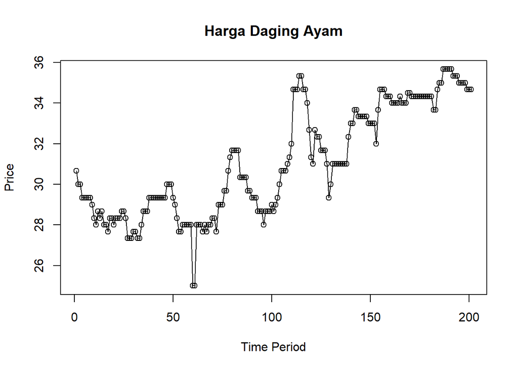

```r
ts.plot(datachicken.ts, xlab="Time Period", ylab="Price",
        main = "Harga Daging Ayam")
#membuat titik2 di plot data
points(datachicken.ts)
```

Pada plot tersebut, terlihat bahwa data berpola trend. Metode pemulusan yang cocok adalah Double Moving Average (DMA) dan Double Exponential Smoothing (DES).

# Pemulusan (Smoothing)

## Double Moving Average (DMA)

### Pembagian Data

```r
#membagi 86% data latih (training) dan 14% data uji (testing)
training_ma <- datachicken[1:173,]
testing_ma <- datachicken[174:201,]
train_ma.ts <- ts(training_ma$Price)
test_ma.ts <- ts(testing_ma$Price)
```

### Eksplorasi Data

Eksplorasi data dilakukan pada keseluruhan data, data latih serta data uji menggunakan plot data deret waktu.

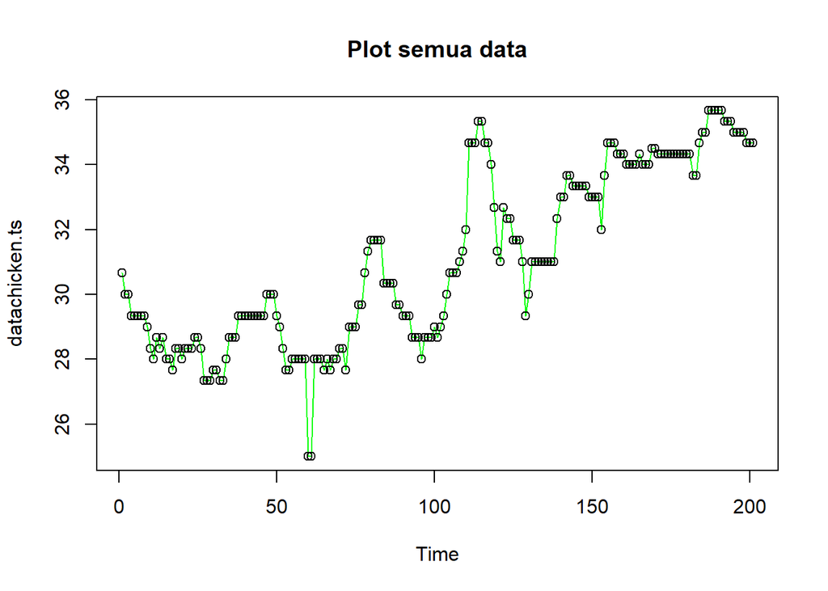

```r
#eksplorasi keseluruhan data
plot(datachicken.ts, col="green",main="Plot semua data")
points(datachicken.ts)
```

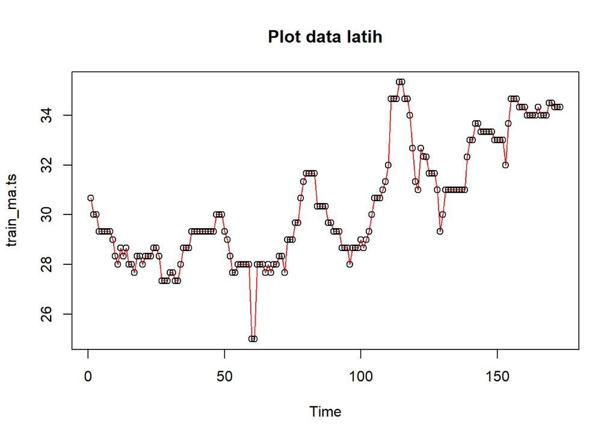

```r
#eksplorasi data latih
plot(train_ma.ts, col="red",main="Plot data latih")
points(train_ma.ts)
```

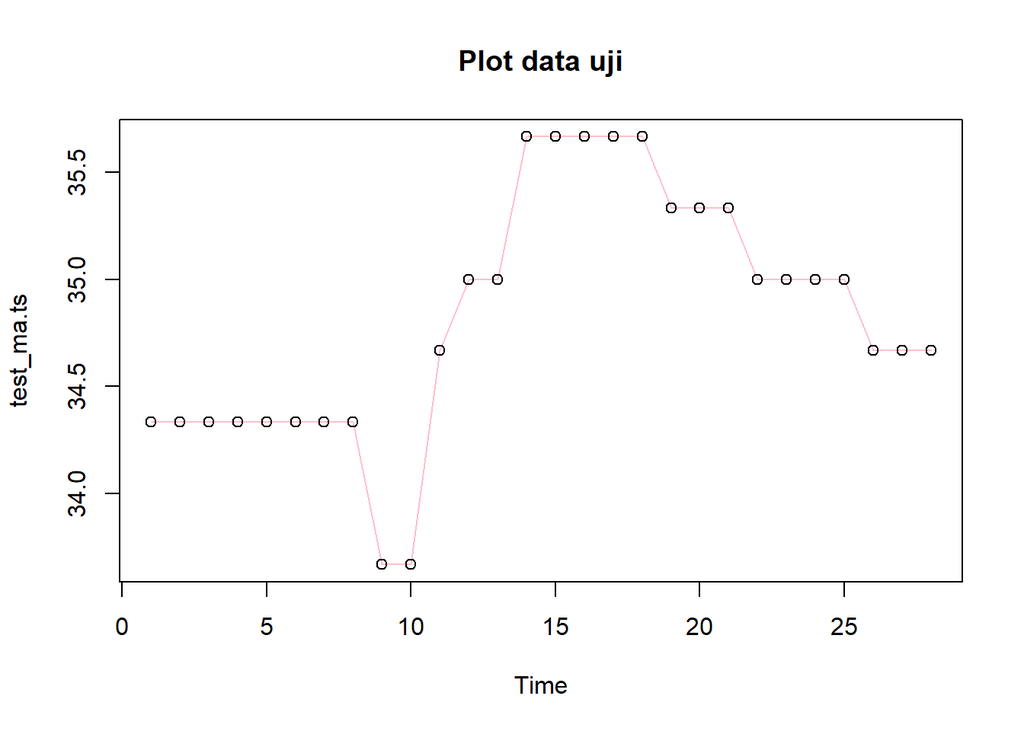

```r
#eksplorasi data uji
plot(test_ma.ts, col="pink",main="Plot data uji")
points(test_ma.ts)
```

Eksplorasi data juga dapat dilakukan menggunakan package `ggplot2` .

```r
#Eksplorasi dengan GGPLOT

library(ggplot2)
ggplot() +
  geom_line(data = training_ma, aes(x = Periode, y = Price, col = "Data Latih")) +
  geom_line(data = testing_ma, aes(x = Periode, y = Price, col = "Data Uji")) +
  labs(x = "Periode Waktu", y = "Harga Rata-rata", color = "Legend") +
  scale_colour_manual(name="Keterangan:", breaks = c("Data Latih", "Data Uji"),
                      values = c("purple", "red")) +
  theme_bw() + theme(legend.position = "bottom",
                     plot.caption = element_text(hjust=0.5, size=13))
```

[output not shown]

### Metode DMA

Metode pemulusan Double Moving Average (DMA) pada dasarnya mirip dengan SMA. Namun demikian, metode ini lebih cocok digunakan untuk pola data trend. Proses pemulusan dengan rata rata dalam metode ini dilakukan sebanyak 2 kali.

```r
data.sma <- SMA(train_ma.ts, n=4)

dma <- SMA(data.sma, n = 4)
At <- 2*data.sma - dma
Bt <- 2/(4-1)*(data.sma - dma)
data.dma<- At+Bt
data.ramal2<- c(NA, data.dma)

t = 1:28
f = c()

for (i in t) {
  f[i] = At[length(At)] + Bt[length(Bt)]*(i)
}

data.gab2 <- cbind(aktual = c(train_ma.ts,rep(NA,28)), pemulusan1 = c(data.sma,rep(NA,28)),pemulusan2 = c(data.dma, rep(NA,28)),At = c(At, rep(NA,28)), Bt = c(Bt,rep(NA,28)),ramalan = c(data.ramal2, f[-1]))
data.gab2
```

```
##        aktual pemulusan1 pemulusan2       At            Bt  ramalan
##   [1,] 30.667         NA         NA       NA            NA       NA
##   [2,] 30.000         NA         NA       NA            NA       NA
##   [3,] 30.000         NA         NA       NA            NA       NA
##   [4,] 29.333   30.00000         NA       NA            NA       NA
##   [5,] 29.333   29.66650         NA       NA            NA       NA
##   [6,] 29.333   29.49975         NA       NA            NA       NA
##   [7,] 29.333   29.33300   28.84665 29.04119 -1.945417e-01       NA
##   [8,] 29.333   29.33300   29.12456 29.20794 -8.337500e-02 28.84665
##   [9,] 29.000   29.24975   29.07621 29.14562 -6.941667e-02 29.12456
##  [10,] 28.333   28.99975   28.61788 28.77063 -1.527500e-01 29.07621
##  [11,] 28.000   28.66650   28.00692 28.27075 -2.638333e-01 28.61788
##  [12,] 28.667   28.50000   27.91000 28.14600 -2.360000e-01 28.00692
##  [13,] 28.333   28.33325   27.84721 28.04163 -1.944167e-01 27.91000
##  [14,] 28.667   28.41675   28.31279 28.35438 -4.158333e-02 27.84721
```

[output cut: 187 more lines]

### Visualisasi

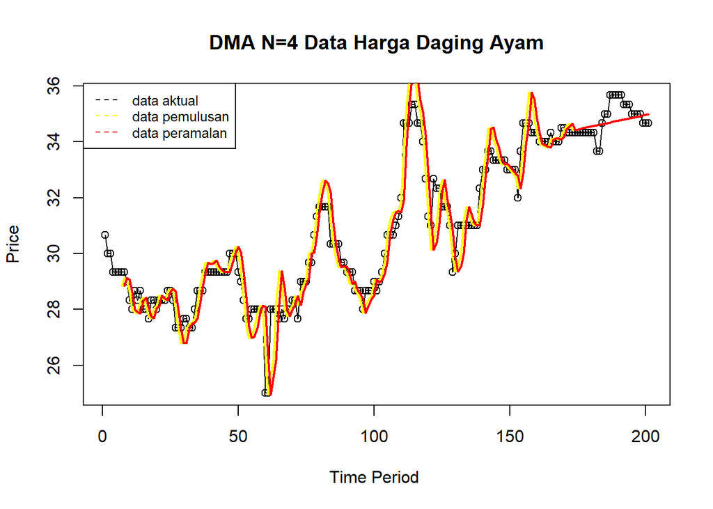

```r
ts.plot(datachicken.ts, xlab="Time Period ", ylab="Price", main= "DMA N=4 Data Harga Daging Ayam")
points(datachicken.ts)
lines(data.gab2[,3],col="yellow",lwd=2)
lines(data.gab2[,6],col="red",lwd=2)
legend("topleft",c("data aktual","data pemulusan","data peramalan"), lty=8, col=c("black","yellow","red"), cex=0.8)
```

### Akurasi Data Latih

```r
error_train.dma = train_ma.ts-data.ramal2[1:length(train_ma.ts)]
SSE_train.dma = sum(error_train.dma[8:length(train_ma.ts)]^2)
MSE_train.dma = mean(error_train.dma[8:length(train_ma.ts)]^2)
MAPE_train.dma = mean(abs((error_train.dma[8:length(train_ma.ts)]/train_ma.ts[8:length(train_ma.ts)])*100))

akurasi_train.dma <- matrix(c(SSE_train.dma, MSE_train.dma, MAPE_train.dma))
row.names(akurasi_train.dma)<- c("SSE", "MSE", "MAPE")
colnames(akurasi_train.dma) <- c("Akurasi m = 4")
akurasi_train.dma
```

```
##      Akurasi m = 4
## SSE    123.8826868
## MSE      0.7462812
## MAPE     2.0460170
```

Perhitungan akurasi menggunakan data latih menghasilkan nilai MAPE yang kurang dari 10% sehingga nilai akurasi ini dapat dikategorikan sebagai sangat baik.

### Akurasi Data Uji

```r
error_test.dma = test_ma.ts-data.gab2[174:201,6]
SSE_test.dma = sum(error_test.dma^2)
MSE_test.dma = mean(error_test.dma^2)
MAPE_test.dma = mean(abs((error_test.dma/test_ma.ts*100)))

akurasi_test.dma <- matrix(c(SSE_test.dma, MSE_test.dma, MAPE_test.dma))
row.names(akurasi_test.dma)<- c("SSE", "MSE", "MAPE")
colnames(akurasi_test.dma) <- c("Akurasi m = 4")
akurasi_test.dma
```

```
##      Akurasi m = 4
## SSE      7.6421739
## MSE      0.2729348
## MAPE     1.1650293
```

Perhitungan akurasi menggunakan data uji menghasilkan nilai MAPE yang kurang dari 10% sehingga nilai akurasi ini dapat dikategorikan sebagai sangat baik.

## Double Exponential Smoothing (DES)

Metode *Exponential Smoothing* adalah metode pemulusan dengan melakukan pembobotan menurun secara eksponensial. Nilai yang lebih baru diberi bobot yang lebih besar dari nilai terdahulu. Terdapat satu atau lebih parameter pemulusan yang ditentukan secara eksplisit dan hasil pemilihan parameter tersebut akan menentukan bobot yang akan diberikan pada nilai pengamatan.

### Pembagian Data

Pembagian data latih dan data uji dilakukan dengan perbandingan 86% data latih dan 14% data uji.

```r
#membagi 86% data latih (training) dan 14% data uji (testing)
training <- datachicken[1:173,]
testing  <- datachicken[174:201,]
train.ts <- ts(training$Price)
test.ts  <- ts(testing$Price)
```

### Eksplorasi Data

Membuat plot data deret waktu untuk keseluruhan data, data latih, dan data uji.

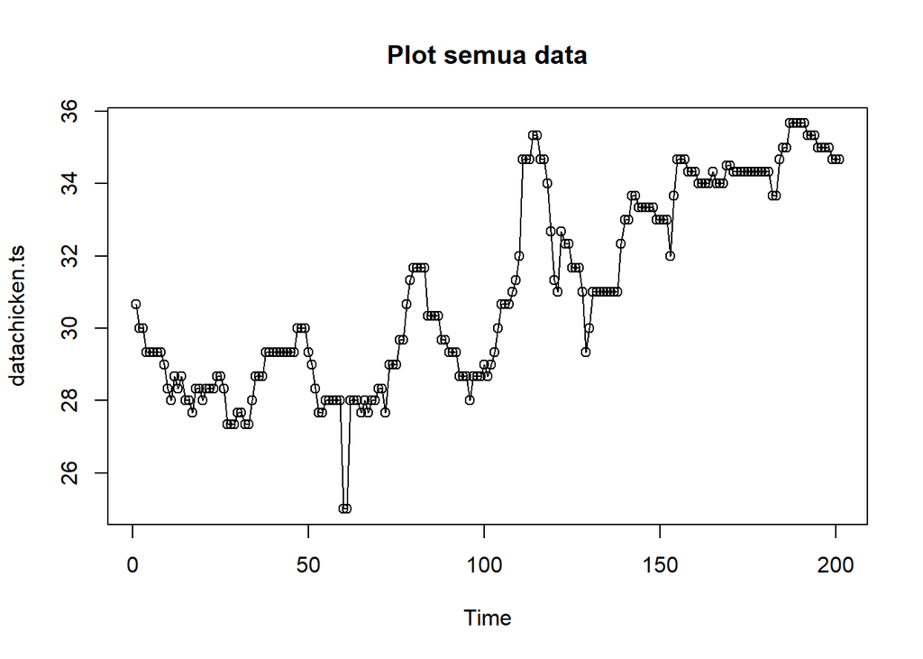

```r
#eksplorasi data
plot(datachicken.ts, col="black",main="Plot semua data")
points(datachicken.ts)
```

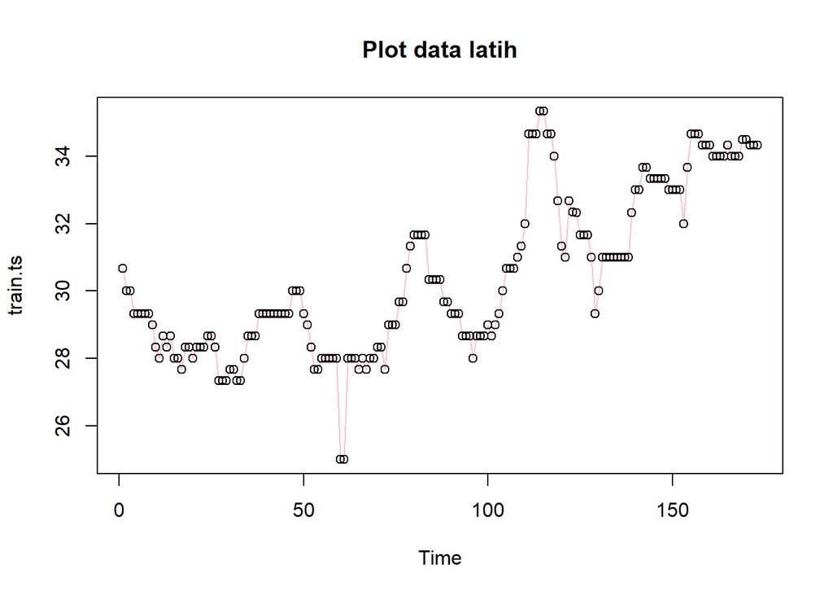

```r
plot(train.ts, col="pink",main="Plot data latih")
points(train.ts)
```

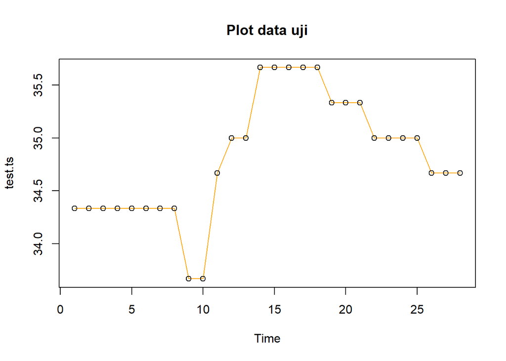

```r
plot(test.ts, col="orange",main="Plot data uji")
points(test.ts)
```

Eksplorasi data juga dapat dilakukan menggunakan package `ggplot2` .

```r
#Eksplorasi dengan GGPLOT
library(ggplot2)
ggplot() +
  geom_line(data = training, aes(x = Periode, y = Price, col = "Data Latih")) +
  geom_line(data = testing, aes(x = Periode, y = Price, col = "Data Uji")) +
  labs(x = "Periode Waktu", y = "Harga Rata-rata", color = "Legend") +
  scale_colour_manual(name="Keterangan:", breaks = c("Data Latih", "Data Uji"),
                      values = c("purple", "red")) +
  theme_bw() + theme(legend.position = "bottom",
                     plot.caption = element_text(hjust=0.5, size=12))
```

[output not shown]

### Metode DES

Metode pemulusan DES digunakan untuk data yang memiliki pola tren. Metode DES adalah metode semacam SES, hanya saja dilakukan dua kali, yaitu pertama untuk tahapan ‘level’ dan kedua untuk tahapan ‘tren’. Pemulusan menggunakan metode ini akan menghasilkan peramalan tidak konstan untuk periode berikutnya.

Pemulusan dengan metode DES ini akan menggunakan fungsi `HoltWinters()` . Nilai argumen `beta` diinisialisasi bersamaan dengan nilai `alpha` dan nilai argumen `gamma` dibuat `FALSE`.

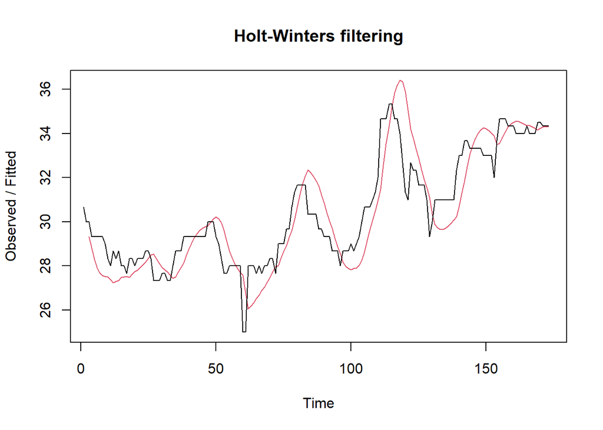

```r
#beta=0.2 dan alpha=0.2
des.1<- HoltWinters(train.ts, gamma = FALSE, beta = 0.2, alpha = 0.2)
plot(des.1)
```

```r
#ramalan
ramalandes1<- forecast(des.1, h=28)     #h = panjang periode
ramalandes1
```

```
##     Point Forecast    Lo 80    Hi 80    Lo 95    Hi 95
## 174       34.33264 32.78461 35.88067 31.96513 36.70015
## 175       34.34236 32.75037 35.93435 31.90762 36.77710
## 176       34.35208 32.70213 36.00202 31.82870 36.87545
## 177       34.36179 32.63909 36.08450 31.72715 36.99644
## 178       34.37151 32.56091 36.18211 31.60243 37.14059
## 179       34.38123 32.46767 36.29479 31.45469 37.30776
## 180       34.39095 32.35978 36.42211 31.28454 37.49735
## 181       34.40066 32.23785 36.56348 31.09292 37.70841
## 182       34.41038 32.10262 36.71814 30.88096 37.93980
## 183       34.42010 31.95488 36.88531 30.64988 38.19032
## 184       34.42982 31.79543 37.06420 30.40087 38.45876
## 185       34.43953 31.62501 37.25406 30.13509 38.74398
## 186       34.44925 31.44431 37.45419 29.85360 39.04491
## 187       34.45897 31.25398 37.66395 29.55736 39.36057
## 188       34.46869 31.05458 37.88279 29.24726 39.69011
## 189       34.47840 30.84663 38.11018 28.92408 40.03273
## 190       34.48812 30.63057 38.34567 28.58850 40.38774
## 191       34.49784 30.40681 38.58886 28.24116 40.75452
## 192       34.50756 30.17572 38.83939 27.88258 41.13253
## 193       34.51727 29.93761 39.09694 27.51328 41.52126
## 194       34.52699 29.69277 39.36121 27.13368 41.92030
## 195       34.53671 29.44145 39.63197 26.74418 42.32924
## 196       34.54642 29.18388 39.90897 26.34513 42.74772
## 197       34.55614 28.92029 40.19200 25.93684 43.17544
## 198       34.56586 28.65084 40.48088 25.51961 43.61211
## 199       34.57558 28.37571 40.77544 25.09370 44.05745
## 200       34.58529 28.09507 41.07552 24.65935 44.51124
## 201       34.59501 27.80905 41.38097 24.21678 44.97325
```

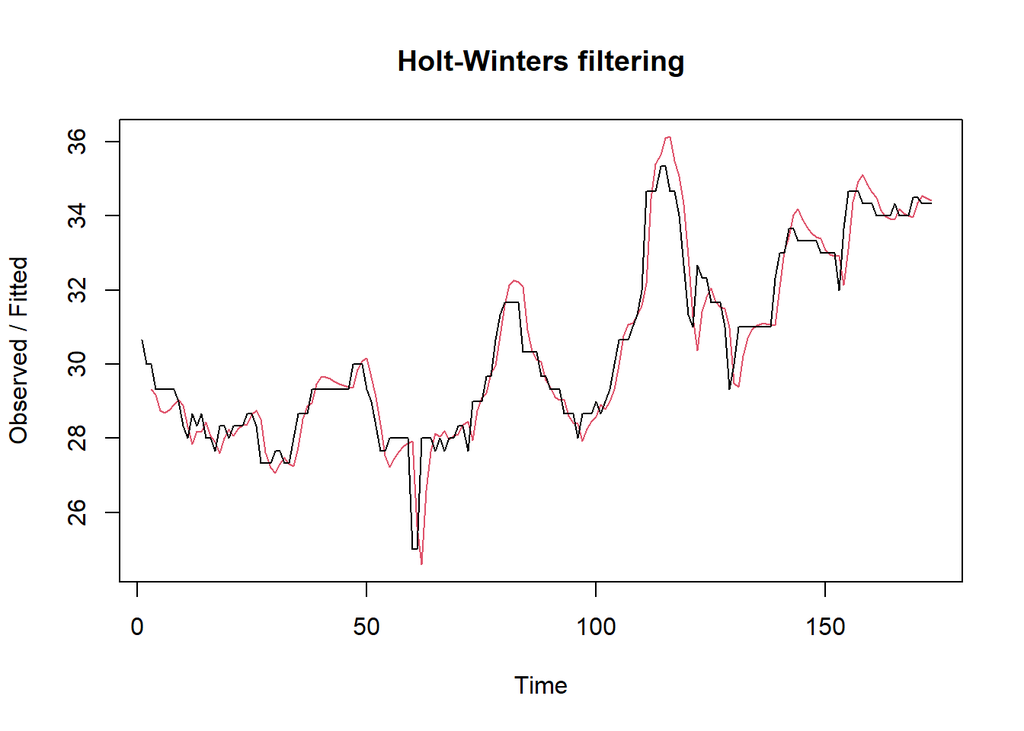

```r
#beta=0.3 dan aplha=0.6
des.2<- HoltWinters(train.ts, gamma = FALSE, beta = 0.3, alpha = 0.6)
plot(des.2)
```

```r
#ramalan
ramalandes2<- forecast(des.2, h=28)
ramalandes2
```

```
##     Point Forecast    Lo 80    Hi 80     Lo 95    Hi 95
## 174       34.38523 33.46739 35.30307 32.981518 35.78895
## 175       34.40194 33.23791 35.56597 32.621715 36.18217
## 176       34.41866 32.95874 35.87857 32.185910 36.65140
## 177       34.43537 32.63921 36.23152 31.688385 37.18235
## 178       34.45208 32.28551 36.61865 31.138596 37.76556
## 179       34.46879 31.90179 37.03579 30.542901 38.39468
## 180       34.48550 31.49098 37.48002 29.905773 39.06523
## 181       34.50221 31.05524 37.94919 29.230518 39.77391
## 182       34.51892 30.59623 38.44161 28.519686 40.51816
## 183       34.53564 30.11530 38.95597 27.775321 41.29595
## 184       34.55235 29.61355 39.49115 26.999105 42.10559
## 185       34.56906 29.09190 40.04622 26.192463 42.94565
## 186       34.58577 28.55115 40.62039 25.356620 43.81492
## 187       34.60248 27.99202 41.21294 24.492649 44.71231
## 188       34.61919 27.41511 41.82327 23.601501 45.63688
## 189       34.63590 26.82099 42.45082 22.684026 46.58778
## 190       34.65261 26.21016 43.09507 21.740996 47.56423
## 191       34.66933 25.58308 43.75557 20.773110 48.56554
## 192       34.68604 24.94016 44.43191 19.781011 49.59106
## 193       34.70275 24.28181 45.12369 18.765292 50.64021
## 194       34.71946 23.60836 45.83056 17.726500 51.71242
## 195       34.73617 22.92016 46.55218 16.665146 52.80720
## 196       34.75288 22.21752 47.28824 15.581706 53.92406
## 197       34.76959 21.50074 48.03845 14.476626 55.06256
## 198       34.78631 20.77007 48.80254 13.350324 56.22229
## 199       34.80302 20.02579 49.58024 12.203198 57.40284
## 200       34.81973 19.26813 50.37132 11.035618 58.60384
## 201       34.83644 18.49734 51.17554  9.847938 59.82494
```

Nilai `y` adalah nilai data deret waktu, `gamma` adalah parameter pemulusan untuk komponen musiman, `beta` adalah parameter pemulusan untuk tren, dan `alpha` adalah parameter pemulusan untuk stasioner, serta `h` adalah banyaknya periode yang akan diramalkan.

### Visualisasi

Membandingkan plot data latih dan data uji adalah sebagai berikut.

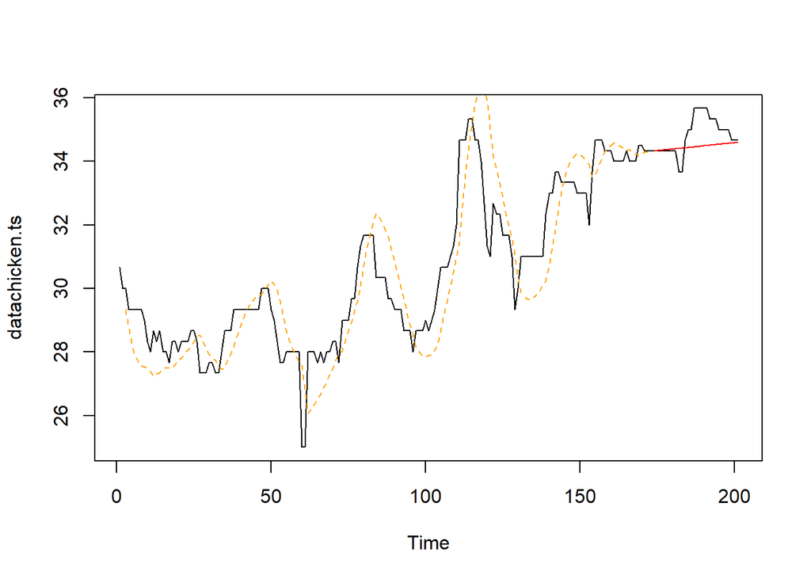

```r
#Visually evaluate the prediction
plot(datachicken.ts)
lines(des.1$fitted[,1], lty=2, col="orange")
lines(ramalandes1$mean, col="red")
```

Untuk mendapatkan nilai parameter optimum dari DES, argumen `alpha` dan `beta` dapat dibuat `NULL` seperti berikut.

```r
#Lamda dan gamma optimum
des.opt<- HoltWinters(train.ts, gamma = FALSE)
des.opt
```

```
## Holt-Winters exponential smoothing with trend and without seasonal component.
##
## Call:
## HoltWinters(x = train.ts, gamma = FALSE)
##
## Smoothing parameters:
##  alpha: 1
##  beta : 0.0762442
##  gamma: FALSE
##
## Coefficients:
##          [,1]
## a 34.33300000
## b  0.03594424
```

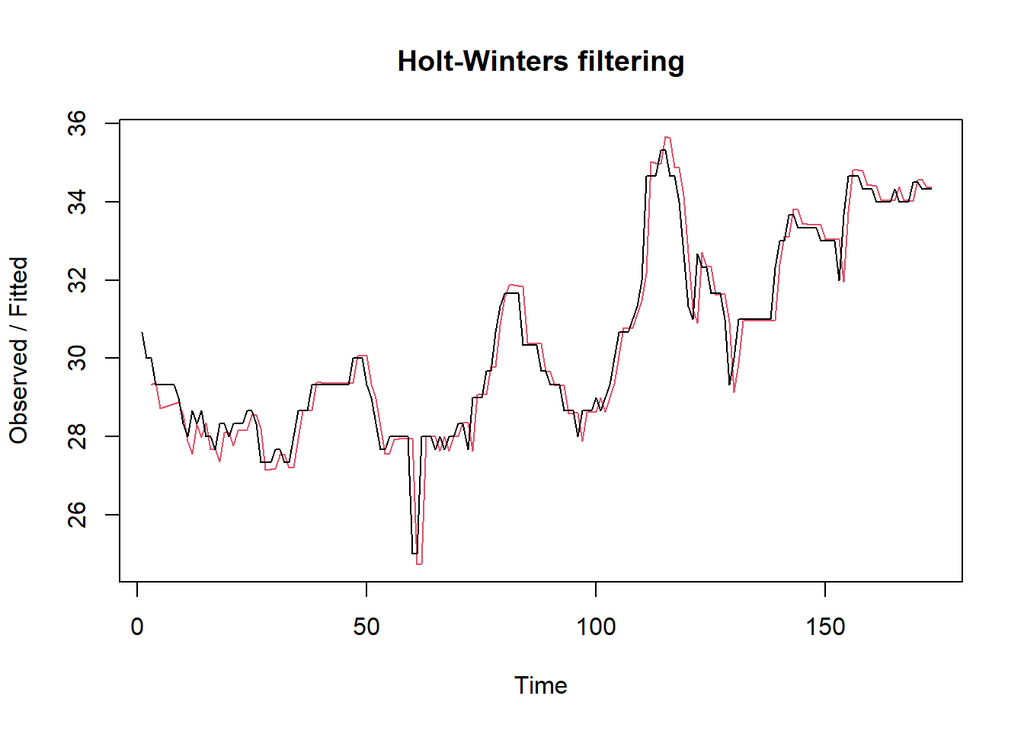

```r
plot(des.opt)
```

```r
#ramalan
ramalandesopt<- forecast(des.opt, h=28)   #h = panjang periode
ramalandesopt
```

```
##     Point Forecast    Lo 80    Hi 80    Lo 95    Hi 95
## 174       34.36894 33.54791 35.18998 33.11328 35.62461
## 175       34.40489 33.19869 35.61108 32.56017 36.24960
## 176       34.44083 32.90778 35.97389 32.09623 36.78544
## 177       34.47678 32.64157 36.31199 31.67006 37.28349
## 178       34.51272 32.38764 36.63780 31.26269 37.76275
## 179       34.54867 32.13993 36.95740 30.86483 38.23250
## 180       34.58461 31.89502 37.27420 30.47123 38.69799
## 181       34.62055 31.65078 37.59033 30.07867 39.16243
## 182       34.65650 31.40584 37.90716 29.68504 39.62795
## 183       34.69244 31.15925 38.22563 29.28890 40.09599
## 184       34.72839 30.91036 38.54641 28.88922 40.56755
## 185       34.76433 30.65869 38.86997 28.48530 41.04336
## 186       34.80028 30.40389 39.19666 28.07659 41.52396
## 187       34.83622 30.14572 39.52672 27.66272 42.00972
## 188       34.87216 29.88397 39.86035 27.24338 42.50094
## 189       34.90811 29.61852 40.19769 26.81838 42.99783
## 190       34.94405 29.34926 40.53884 26.38756 43.50054
## 191       34.98000 29.07612 40.88387 25.95080 44.00919
## 192       35.01594 28.79905 41.23283 25.50803 44.52385
## 193       35.05188 28.51801 41.58576 25.05919 45.04458
## 194       35.08783 28.23299 41.94267 24.60425 45.57141
## 195       35.12377 27.94396 42.30359 24.14319 46.10435
## 196       35.15972 27.65093 42.66850 23.67602 46.64342
## 197       35.19566 27.35390 43.03742 23.20273 47.18860
## 198       35.23161 27.05289 43.41032 22.72334 47.73987
## 199       35.26755 26.74790 43.78720 22.23787 48.29723
## 200       35.30349 26.43895 44.16804 21.74634 48.86065
## 201       35.33944 26.12606 44.55282 21.24879 49.43008
```

### Akurasi Data Latih

```r
#Akurasi Data Training
ssedes.train1<-des.1$SSE
msedes.train1<-ssedes.train1/length(train.ts)
sisaandes1<-ramalandes1$residuals
head(sisaandes1)
```

```
## Time Series:
## Start = 1
## End = 6
## Frequency = 1
## [1]       NA       NA 0.667000 0.506920 1.025579 1.399483
```

```r
mapedes.train1 <- sum(abs(sisaandes1[3:length(train.ts)]/train.ts[3:length(train.ts)])
                      *100)/length(train.ts)

akurasides.1 <- matrix(c(ssedes.train1,msedes.train1,mapedes.train1))
row.names(akurasides.1)<- c("SSE", "MSE", "MAPE")
colnames(akurasides.1) <- c("Akurasi lamda=0.2 dan gamma=0.2")
akurasides.1
```

```
##      Akurasi lamda=0.2 dan gamma=0.2
## SSE                       249.722312
## MSE                         1.443482
## MAPE                        3.112975
```

```r
ssedes.train2<-des.2$SSE
msedes.train2<-ssedes.train2/length(train.ts)
sisaandes2<-ramalandes2$residuals
head(sisaandes2)
```

```
## Time Series:
## Start = 1
## End = 6
## Frequency = 1
## [1]        NA        NA 0.6670000 0.1467400 0.5792228 0.6479558
```

```r
mapedes.train2 <- sum(abs(sisaandes2[3:length(train.ts)]/train.ts[3:length(train.ts)])
                      *100)/length(train.ts)

akurasides.2 <- matrix(c(ssedes.train2,msedes.train2,mapedes.train2))
row.names(akurasides.2)<- c("SSE", "MSE", "MAPE")
colnames(akurasides.2) <- c("Akurasi lamda=0.6 dan gamma=0.3")
akurasides.2
```

```
##      Akurasi lamda=0.6 dan gamma=0.3
## SSE                       87.2832538
## MSE                        0.5045275
## MAPE                       1.5694554
```

Hasil akurasi dari data latih didapatkan skenario 2 dengan lamda=0.6 dan gamma=0.3 memiliki hasil yang lebih baik. Hal tersebut dapat dilihat berdasarkan nilai SSE, MSE,dan MAPE nya yang bernilai lebih kecil dibandinglan dengan skenario 1. Namun, kedua skenario tersebut dapat dikategorikan peramalan sangat baik berdasarkan nilai MAPE-nya.

### Akurasi Data Uji

```r
#Akurasi Data Testing
selisihdes1 <- ramalandes1$mean - testing$Price
selisihdes1
```

```
## Time Series:
## Start = 174
## End = 201
## Frequency = 1
##  [1] -0.000359482  0.009357991  0.019075464  0.028792936  0.038510409
##  [6]  0.048227882  0.057945355  0.067662828  0.743380301  0.753097773
## [11] -0.237184754 -0.560467281 -0.550749808 -1.208032335 -1.198314862
## [16] -1.188597390 -1.178879917 -1.169162444 -0.825444971 -0.815727498
## [21] -0.806010025 -0.463292553 -0.453575080 -0.443857607 -0.434140134
## [26] -0.091422661 -0.081705188 -0.071987716
```

```r
SSEtestingdes1<-sum(selisihdes1^2)
MSEtestingdes1<-SSEtestingdes1/length(testing$Price)
MAPEtestingdes1<-sum(abs(selisihdes1/testing$Price)*100)/length(testing$Price)

selisihdes2<-ramalandes2$mean-testing$Price
selisihdes2
```

```
## Time Series:
## Start = 174
## End = 201
## Frequency = 1
##  [1]  0.05223333  0.06894466  0.08565599  0.10236732  0.11907865  0.13578998
##  [7]  0.15250131  0.16921264  0.85192396  0.86863529 -0.11465338 -0.43094205
## [13] -0.41423072 -1.06451939 -1.04780806 -1.03109673 -1.01438540 -0.99767407
## [19] -0.64696274 -0.63025142 -0.61354009 -0.26382876 -0.24711743 -0.23040610
## [25] -0.21369477  0.13601656  0.15272789  0.16943922
```

```r
SSEtestingdes2<-sum(selisihdes2^2)
MSEtestingdes2<-SSEtestingdes2/length(testing$Price)
MAPEtestingdes2<-sum(abs(selisihdes2/testing$Price)*100)/length(testing$Price)

selisihdesopt<-ramalandesopt$mean-testing$Price
selisihdesopt
```

```
## Time Series:
## Start = 174
## End = 201
## Frequency = 1
##  [1]  0.03594424  0.07188849  0.10783273  0.14377697  0.17972121  0.21566546
##  [7]  0.25160970  0.28755394  0.98949818  1.02544243  0.06138667 -0.23566909
## [13] -0.19972485 -0.83078060 -0.79483636 -0.75889212 -0.72294788 -0.68700363
## [19] -0.31705939 -0.28111515 -0.24517090  0.12377334  0.15971758  0.19566182
## [25]  0.23160607  0.60055031  0.63649455  0.67243879
```

```r
SSEtestingdesopt<-sum(selisihdesopt^2)
MSEtestingdesopt<-SSEtestingdesopt/length(testing$Price)
MAPEtestingdesopt<-sum(abs(selisihdesopt/testing$Price)*100)/length(testing$Price)

akurasitestingdes <-
  matrix(c(SSEtestingdes1,MSEtestingdes1,MAPEtestingdes1,SSEtestingdes2,MSEtestingdes2,
           MAPEtestingdes2,SSEtestingdesopt,MSEtestingdesopt,MAPEtestingdesopt),
         nrow=3,ncol=3)
row.names(akurasitestingdes)<- c("SSE", "MSE", "MAPE")
colnames(akurasitestingdes) <- c("des ske1","des ske2","des opt")
akurasitestingdes
```

```
##        des ske1  des ske2   des opt
## SSE  11.6937612 8.7713163 6.8762844
## MSE   0.4176343 0.3132613 0.2455816
## MAPE  1.3754988 1.2247185 1.1335412
```

# Perbandingan Metode Pemulusan DMA dan DES

```r
perbandingan <-
  matrix(c(SSE_test.dma, MSE_test.dma, MAPE_test.dma, SSEtestingdesopt,MSEtestingdesopt,MAPEtestingdesopt),
         nrow=3,ncol=2)
row.names(perbandingan)<- c("SSE", "MSE", "MAPE")
colnames(perbandingan) <- c("DMA","DES")
perbandingan
```

```
##            DMA       DES
## SSE  7.6421739 6.8762844
## MSE  0.2729348 0.2455816
## MAPE 1.1650293 1.1335412
```

Kedua metode tersebut dapat dibandingkan dengan menggunakan ukuran akurasi yang sama. Berdasarkan nilai SSE, MSE, dan MAPE, metode DES lebih baik karena memiliki ukuran akurasi yang lebih kecil dibandingkan dengan metode DMA. Berdasarkan nilai MAPE nya kedua metode tersebut memberikan peramalan dengan akurasi yang sangat baik karena kurang dari 10%.